# Regressão Logística - Cancelamento de reservas

## Bibliotecas

```python
import pandas as pd
import seaborn as sns
import matplotlib.pyplot as plt
from sklearn.model_selection import train_test_split
from sklearn.linear_model import LogisticRegression
from sklearn.metrics import roc_auc_score, roc_curve, precision_score, recall_score, confusion_matrix, classification_report
import numpy as np

sns.set_theme(style="whitegrid", palette="Set2")
```

## Leitura dos dados

O dado abaixo contém informações de dois hotéis de Portugal (um resort e um hotel na cidade de Lisboa)

```python
df = pd.read_csv('hotel_bookings.csv')
df.head()
```

|  | hotel | is_canceled | lead_time | arrival_date_year | arrival_date_month | arrival_date_week_number | arrival_date_day_of_month | stays_in_weekend_nights | stays_in_week_nights | adults | ... | deposit_type | agent | company | days_in_waiting_list | customer_type | adr | required_car_parking_spaces | total_of_special_requests | reservation_status | reservation_status_date |
| --- | --- | --- | --- | --- | --- | --- | --- | --- | --- | --- | --- | --- | --- | --- | --- | --- | --- | --- | --- | --- | --- |
| 0 | Resort Hotel | 0 | 342 | 2015 | July | 27 | 1 | 0 | 0 | 2 | ... | No Deposit | NaN | NaN | 0 | Transient | 0.0 | 0 | 0 | Check-Out | 2015-07-01 |
| 1 | Resort Hotel | 0 | 737 | 2015 | July | 27 | 1 | 0 | 0 | 2 | ... | No Deposit | NaN | NaN | 0 | Transient | 0.0 | 0 | 0 | Check-Out | 2015-07-01 |
| 2 | Resort Hotel | 0 | 7 | 2015 | July | 27 | 1 | 0 | 1 | 1 | ... | No Deposit | NaN | NaN | 0 | Transient | 75.0 | 0 | 0 | Check-Out | 2015-07-02 |
| 3 | Resort Hotel | 0 | 13 | 2015 | July | 27 | 1 | 0 | 1 | 1 | ... | No Deposit | 304.0 | NaN | 0 | Transient | 75.0 | 0 | 0 | Check-Out | 2015-07-02 |
| 4 | Resort Hotel | 0 | 14 | 2015 | July | 27 | 1 | 0 | 2 | 2 | ... | No Deposit | 240.0 | NaN | 0 | Transient | 98.0 | 0 | 1 | Check-Out | 2015-07-03 |

5 rows × 32 columns

```python
df.columns
```

```
Index(['hotel', 'is_canceled', 'lead_time', 'arrival_date_year',
       'arrival_date_month', 'arrival_date_week_number',
       'arrival_date_day_of_month', 'stays_in_weekend_nights',
       'stays_in_week_nights', 'adults', 'children', 'babies', 'meal',
       'country', 'market_segment', 'distribution_channel',
       'is_repeated_guest', 'previous_cancellations',
       'previous_bookings_not_canceled', 'reserved_room_type',
       'assigned_room_type', 'booking_changes', 'deposit_type', 'agent',
       'company', 'days_in_waiting_list', 'customer_type', 'adr',
       'required_car_parking_spaces', 'total_of_special_requests',
       'reservation_status', 'reservation_status_date'],
      dtype='object')
```

```python
df.describe()
```

|  | is_canceled | lead_time | arrival_date_year | arrival_date_week_number | arrival_date_day_of_month | stays_in_weekend_nights | stays_in_week_nights | adults | children | babies | is_repeated_guest | previous_cancellations | previous_bookings_not_canceled | booking_changes | agent | company | days_in_waiting_list | adr | required_car_parking_spaces | total_of_special_requests |
| --- | --- | --- | --- | --- | --- | --- | --- | --- | --- | --- | --- | --- | --- | --- | --- | --- | --- | --- | --- | --- |
| count | 119390.000000 | 119390.000000 | 119390.000000 | 119390.000000 | 119390.000000 | 119390.000000 | 119390.000000 | 119390.000000 | 119386.000000 | 119390.000000 | 119390.000000 | 119390.000000 | 119390.000000 | 119390.000000 | 103050.000000 | 6797.000000 | 119390.000000 | 119390.000000 | 119390.000000 | 119390.000000 |
| mean | 0.370416 | 104.011416 | 2016.156554 | 27.165173 | 15.798241 | 0.927599 | 2.500302 | 1.856403 | 0.103890 | 0.007949 | 0.031912 | 0.087118 | 0.137097 | 0.221124 | 86.693382 | 189.266735 | 2.321149 | 101.831122 | 0.062518 | 0.571363 |
| std | 0.482918 | 106.863097 | 0.707476 | 13.605138 | 8.780829 | 0.998613 | 1.908286 | 0.579261 | 0.398561 | 0.097436 | 0.175767 | 0.844336 | 1.497437 | 0.652306 | 110.774548 | 131.655015 | 17.594721 | 50.535790 | 0.245291 | 0.792798 |
| min | 0.000000 | 0.000000 | 2015.000000 | 1.000000 | 1.000000 | 0.000000 | 0.000000 | 0.000000 | 0.000000 | 0.000000 | 0.000000 | 0.000000 | 0.000000 | 0.000000 | 1.000000 | 6.000000 | 0.000000 | -6.380000 | 0.000000 | 0.000000 |
| 25% | 0.000000 | 18.000000 | 2016.000000 | 16.000000 | 8.000000 | 0.000000 | 1.000000 | 2.000000 | 0.000000 | 0.000000 | 0.000000 | 0.000000 | 0.000000 | 0.000000 | 9.000000 | 62.000000 | 0.000000 | 69.290000 | 0.000000 | 0.000000 |
| 50% | 0.000000 | 69.000000 | 2016.000000 | 28.000000 | 16.000000 | 1.000000 | 2.000000 | 2.000000 | 0.000000 | 0.000000 | 0.000000 | 0.000000 | 0.000000 | 0.000000 | 14.000000 | 179.000000 | 0.000000 | 94.575000 | 0.000000 | 0.000000 |
| 75% | 1.000000 | 160.000000 | 2017.000000 | 38.000000 | 23.000000 | 2.000000 | 3.000000 | 2.000000 | 0.000000 | 0.000000 | 0.000000 | 0.000000 | 0.000000 | 0.000000 | 229.000000 | 270.000000 | 0.000000 | 126.000000 | 0.000000 | 1.000000 |
| max | 1.000000 | 737.000000 | 2017.000000 | 53.000000 | 31.000000 | 19.000000 | 50.000000 | 55.000000 | 10.000000 | 10.000000 | 1.000000 | 26.000000 | 72.000000 | 21.000000 | 535.000000 | 543.000000 | 391.000000 | 5400.000000 | 8.000000 | 5.000000 |

```python
df.info()
```

```
<class 'pandas.core.frame.DataFrame'>
RangeIndex: 119390 entries, 0 to 119389
Data columns (total 32 columns):
 #   Column                          Non-Null Count   Dtype
---  ------                          --------------   -----
 0   hotel                           119390 non-null  object
 1   is_canceled                     119390 non-null  int64
 2   lead_time                       119390 non-null  int64
 3   arrival_date_year               119390 non-null  int64
 4   arrival_date_month              119390 non-null  object
 5   arrival_date_week_number        119390 non-null  int64
 6   arrival_date_day_of_month       119390 non-null  int64
 7   stays_in_weekend_nights         119390 non-null  int64
 8   stays_in_week_nights            119390 non-null  int64
 9   adults                          119390 non-null  int64
```

[output cut: 24 more lines]

### Ajustes nos dados

```python
df.isna().sum()
```

```
hotel                                  0
is_canceled                            0
lead_time                              0
arrival_date_year                      0
arrival_date_month                     0
arrival_date_week_number               0
arrival_date_day_of_month              0
stays_in_weekend_nights                0
stays_in_week_nights                   0
adults                                 0
children                               4
babies                                 0
meal                                   0
country                              488
market_segment                         0
distribution_channel                   0
is_repeated_guest                      0
previous_cancellations                 0
previous_bookings_not_canceled         0
reserved_room_type                     0
assigned_room_type                     0
booking_changes                        0
deposit_type                           0
agent                              16340
company                           112593
days_in_waiting_list                   0
customer_type                          0
adr                                    0
required_car_parking_spaces            0
total_of_special_requests              0
reservation_status                     0
reservation_status_date                0
dtype: int64
```

Há algumas colunas ("children", "country", "agent" e "company") com valores vazios.

**Observação:**

- "agent": ID da agência de viagens que fez a reserva.
- "company": ID da empresa/entidade que efetuou a reserva ou responsável pelo pagamento da reserva.

Se o registro não possui o ID da agência ou da companhia, isso pode signifcar que o dado é privado. No caso da agência, a reversa pode ter sido feita de forma direta também. Dessa forma, esses valores serão substituídos por 0.

Valores faltantes de "children" serão trocados por 0. No caso de "country", os valores faltantes serão trocados por "Unknown".

```python
df = df.fillna({"children": 0, "country": "Unknown", "agent": 0, "company": 0})
```

```python
features = df.drop(columns=['is_canceled'])
```

```python
# Normalizando tipos de refeição
# Segundo a documentação, "Undefined" e "SC" significam que não há refeição no pacote

df["meal"].replace("Undefined", "SC", inplace=True)
```

## Análise dos dados

### Distribuição de clientes que cancelaram e não cancelaram

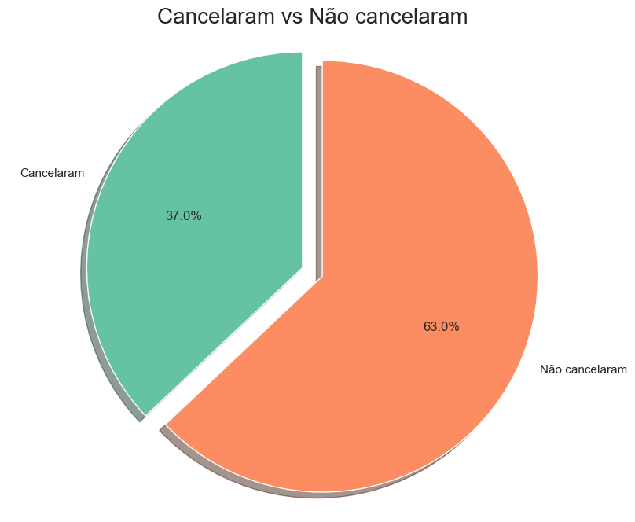

```python
labels = ['Cancelaram', 'Não cancelaram']
sizes = [df.is_canceled[df['is_canceled'] == 1].count(), df.is_canceled[df['is_canceled'] == 0].count()]
explode = (0, 0.1)

fig1, ax1 = plt.subplots(figsize=(10, 8))
ax1.pie(sizes, explode=explode, labels=labels, autopct='%1.1f%%',
        shadow=True, startangle=90)
ax1.axis('equal')
plt.title("Cancelaram vs Não cancelaram", size=20)
plt.show()
```

### Distribuição dos hotéis

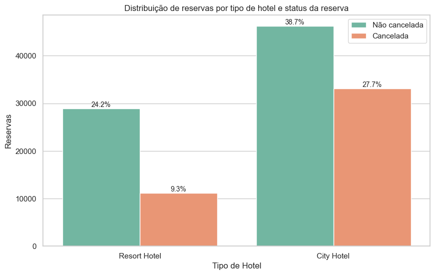

```python
import matplotlib.pyplot as plt
import seaborn as sns

plt.figure(figsize=(10, 6))
ax = sns.countplot(data=df, x="hotel", hue="is_canceled")

total = len(df)
for p in ax.patches:
    height = p.get_height()
    if height > 0:
        width = p.get_width()
        x = p.get_x() + width / 2
        y = height
        percentage = (height / total) * 100
        ax.text(x, y + 10, f'{percentage:.1f}%', ha='center', va='bottom', fontsize=10)

plt.xlabel("Tipo de Hotel")
plt.ylabel("Reservas")
plt.title("Distribuição de reservas por tipo de hotel e status da reserva")
plt.legend(["Não cancelada", "Cancelada"])

plt.show()
```

### Número de pessoas por reserva

```python
df[(df["adults"] + df["children"] + df["babies"]) == 0]
```

|  | hotel | is_canceled | lead_time | arrival_date_year | arrival_date_month | arrival_date_week_number | arrival_date_day_of_month | stays_in_weekend_nights | stays_in_week_nights | adults | ... | deposit_type | agent | company | days_in_waiting_list | customer_type | adr | required_car_parking_spaces | total_of_special_requests | reservation_status | reservation_status_date |
| --- | --- | --- | --- | --- | --- | --- | --- | --- | --- | --- | --- | --- | --- | --- | --- | --- | --- | --- | --- | --- | --- |
| 2224 | Resort Hotel | 0 | 1 | 2015 | October | 41 | 6 | 0 | 3 | 0 | ... | No Deposit | 0.0 | 174.0 | 0 | Transient-Party | 0.00 | 0 | 0 | Check-Out | 2015-10-06 |
| 2409 | Resort Hotel | 0 | 0 | 2015 | October | 42 | 12 | 0 | 0 | 0 | ... | No Deposit | 0.0 | 174.0 | 0 | Transient | 0.00 | 0 | 0 | Check-Out | 2015-10-12 |
| 3181 | Resort Hotel | 0 | 36 | 2015 | November | 47 | 20 | 1 | 2 | 0 | ... | No Deposit | 38.0 | 0.0 | 0 | Transient-Party | 0.00 | 0 | 0 | Check-Out | 2015-11-23 |
| 3684 | Resort Hotel | 0 | 165 | 2015 | December | 53 | 30 | 1 | 4 | 0 | ... | No Deposit | 308.0 | 0.0 | 122 | Transient-Party | 0.00 | 0 | 0 | Check-Out | 2016-01-04 |
| 3708 | Resort Hotel | 0 | 165 | 2015 | December | 53 | 30 | 2 | 4 | 0 | ... | No Deposit | 308.0 | 0.0 | 122 | Transient-Party | 0.00 | 0 | 0 | Check-Out | 2016-01-05 |
| ... | ... | ... | ... | ... | ... | ... | ... | ... | ... | ... | ... | ... | ... | ... | ... | ... | ... | ... | ... | ... | ... |
| 115029 | City Hotel | 0 | 107 | 2017 | June | 26 | 27 | 0 | 3 | 0 | ... | No Deposit | 7.0 | 0.0 | 0 | Transient | 100.80 | 0 | 0 | Check-Out | 2017-06-30 |
| 115091 | City Hotel | 0 | 1 | 2017 | June | 26 | 30 | 0 | 1 | 0 | ... | No Deposit | 0.0 | 0.0 | 0 | Transient | 0.00 | 1 | 1 | Check-Out | 2017-07-01 |
| 116251 | City Hotel | 0 | 44 | 2017 | July | 28 | 15 | 1 | 1 | 0 | ... | No Deposit | 425.0 | 0.0 | 0 | Transient | 73.80 | 0 | 0 | Check-Out | 2017-07-17 |
| 116534 | City Hotel | 0 | 2 | 2017 | July | 28 | 15 | 2 | 5 | 0 | ... | No Deposit | 9.0 | 0.0 | 0 | Transient-Party | 22.86 | 0 | 1 | Check-Out | 2017-07-22 |
| 117087 | City Hotel | 0 | 170 | 2017 | July | 30 | 27 | 0 | 2 | 0 | ... | No Deposit | 52.0 | 0.0 | 0 | Transient | 0.00 | 0 | 0 | Check-Out | 2017-07-29 |

180 rows × 32 columns

```python
# Removendo registros com número de hóspedes = 0

df = df[(df["adults"] + df["children"] + df["babies"]) != 0].reset_index(drop=True)
```

```python
df["num_guests"] = df["adults"] + df["children"] + df["babies"]
```

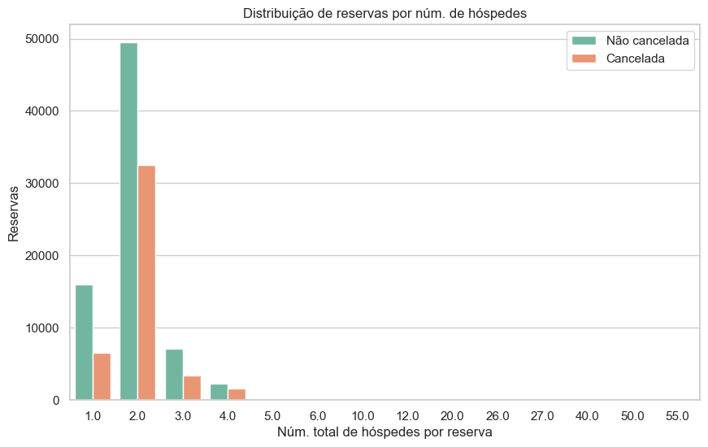

```python
plt.figure(figsize=(10, 6))
sns.countplot(data=df, x="num_guests", hue="is_canceled")

plt.xlabel("Núm. total de hóspedes por reserva")
plt.ylabel("Reservas")
plt.title("Distribuição de reservas por núm. de hóspedes")
plt.legend(["Não cancelada", "Cancelada"])

plt.show()
```

### Tempo entre reserva e chegada

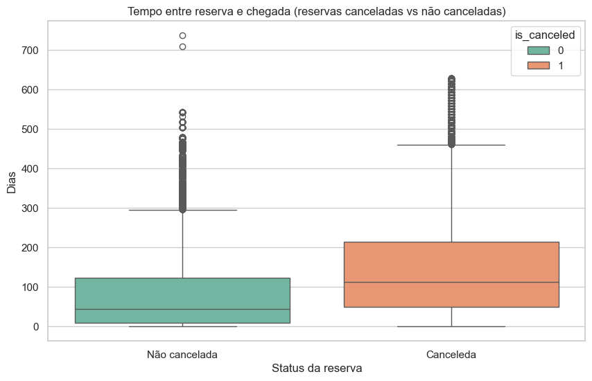

```python
plt.figure(figsize=(10, 6))
sns.boxplot(x=df["is_canceled"], y=df["lead_time"], hue=df["is_canceled"])

plt.xticks([0, 1], ["Não cancelada", "Canceleda"])
plt.xlabel("Status da reserva")
plt.ylabel("Dias")
plt.title("Tempo entre reserva e chegada (reservas canceladas vs não canceladas)")

plt.show()
```

Reservas canceladas tem a tendência de serem feitas com mais antecedência do que reservas não canceladas.

### Distribuição de variáveis numéricas

```python
numerical_data = features.select_dtypes("number")
numerical_data.info()
```

```
<class 'pandas.core.frame.DataFrame'>
RangeIndex: 119390 entries, 0 to 119389
Data columns (total 19 columns):
 #   Column                          Non-Null Count   Dtype
---  ------                          --------------   -----
 0   lead_time                       119390 non-null  int64
 1   arrival_date_year               119390 non-null  int64
 2   arrival_date_week_number        119390 non-null  int64
 3   arrival_date_day_of_month       119390 non-null  int64
 4   stays_in_weekend_nights         119390 non-null  int64
 5   stays_in_week_nights            119390 non-null  int64
 6   adults                          119390 non-null  int64
 7   children                        119390 non-null  float64
 8   babies                          119390 non-null  int64
 9   is_repeated_guest               119390 non-null  int64
 10  previous_cancellations          119390 non-null  int64
 11  previous_bookings_not_canceled  119390 non-null  int64
 12  booking_changes                 119390 non-null  int64
 13  agent                           119390 non-null  float64
 14  company                         119390 non-null  float64
 15  days_in_waiting_list            119390 non-null  int64
 16  adr                             119390 non-null  float64
 17  required_car_parking_spaces     119390 non-null  int64
 18  total_of_special_requests       119390 non-null  int64
dtypes: float64(4), int64(15)
memory usage: 17.3 MB
```

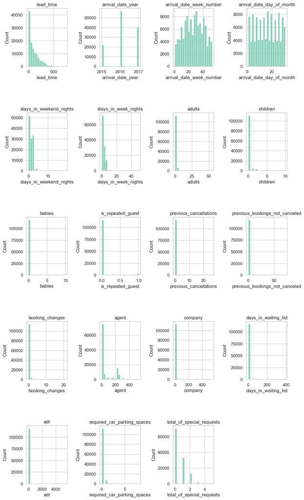

```python
fig, axes = plt.subplots(nrows=5, ncols=4, figsize=(12, 22))

axes = axes.flatten()

for i in range(len(numerical_data.columns), 20):
    axes[i].axis('off')

for i, column in enumerate(numerical_data.columns):
    sns.histplot(numerical_data[column], bins=20, kde=False, ax=axes[i])
    axes[i].set_xlabel(column)
    axes[i].set_title(column)

plt.subplots_adjust(hspace=0.8, wspace=0.8)
plt.show()
```

### Origem dos hóspedes

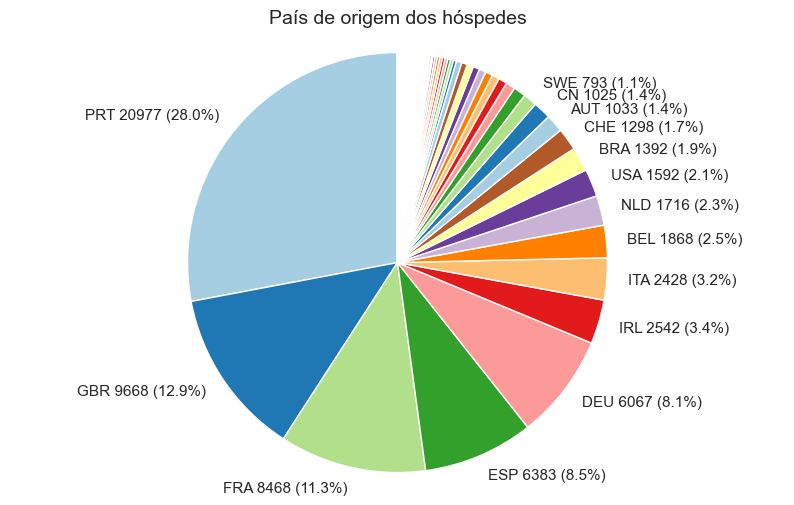

```python
country_dist = pd.DataFrame(df.loc[df["is_canceled"] == 0]["country"].value_counts()).reset_index()

country_dist.rename(columns={"count": "num_guests"}, inplace=True)
total_guests = country_dist["num_guests"].sum()
country_dist["guests %"] = round(country_dist["num_guests"] / total_guests * 100, 2)

plt.figure(figsize=(10, 6))
threshold = 1  # Exibir porcentagem apenas se for >= 2%
labels = [
    f"{name} {num_g} ({pct:.1f}%)" if pct >= threshold else ""
    for name, num_g, pct in zip(country_dist["country"], country_dist["num_guests"], country_dist["guests %"])
]
plt.pie(country_dist["num_guests"], labels=labels,
        startangle=90, colors=plt.cm.Paired.colors)
plt.title("País de origem dos hóspedes", fontsize=14)
plt.axis('equal')

plt.show()
```

### Cancelamentos por tipo de quarto reservado

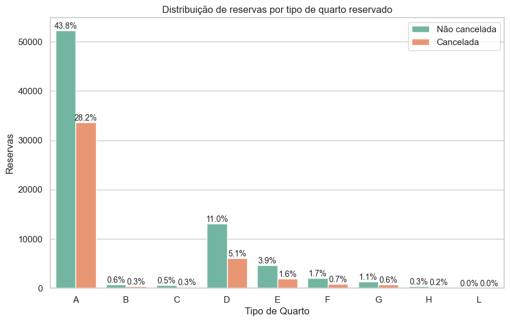

```python
plt.figure(figsize=(10, 6))

sorted_room_types = sorted(df["reserved_room_type"].unique())
ax = sns.countplot(data=df, x="reserved_room_type", hue="is_canceled", order=sorted_room_types)

total = len(df)
for p in ax.patches:
    height = p.get_height()
    if height > 0:
        width = p.get_width()
        x = p.get_x() + width / 2
        y = height
        percentage = (height / total) * 100
        ax.text(x, y + 10, f'{percentage:.1f}%', ha='center', va='bottom', fontsize=10)

plt.xlabel("Tipo de Quarto")
plt.ylabel("Reservas")
plt.title("Distribuição de reservas por tipo de quarto reservado")
plt.legend(["Não cancelada", "Cancelada"])

plt.show()
```

### Cancelamentos por tipos de depósito

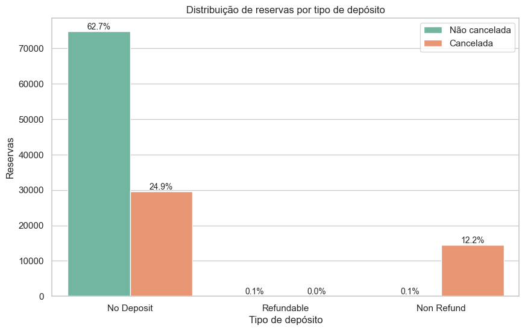

```python
plt.figure(figsize=(10, 6))

ax = sns.countplot(data=df, x="deposit_type", hue="is_canceled")
total = len(df)
for p in ax.patches:
    height = p.get_height()
    if height > 0:
        width = p.get_width()
        x = p.get_x() + width / 2
        y = height
        percentage = (height / total) * 100
        ax.text(x, y + 10, f'{percentage:.1f}%', ha='center', va='bottom', fontsize=10)

plt.xlabel("Tipo de depósito")
plt.ylabel("Reservas")
plt.title("Distribuição de reservas por tipo de depósito")
plt.legend(["Não cancelada", "Cancelada"])

plt.show()
```

### Cancelamentos por canal de distribuição

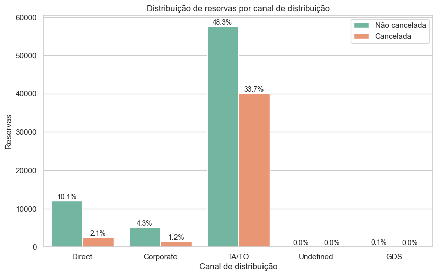

```python
plt.figure(figsize=(10, 6))

ax = sns.countplot(data=df, x="distribution_channel", hue="is_canceled")
total = len(df)
for p in ax.patches:
    height = p.get_height()
    if height > 0:
        width = p.get_width()
        x = p.get_x() + width / 2
        y = height
        percentage = (height / total) * 100
        ax.text(x, y + 10, f'{percentage:.1f}%', ha='center', va='bottom', fontsize=10)

plt.xlabel("Canal de distribuição")
plt.ylabel("Reservas")
plt.title("Distribuição de reservas por canal de distribuição")
plt.legend(["Não cancelada", "Cancelada"])

plt.show()
```

### Cancelamentos por tipo de quarto designado

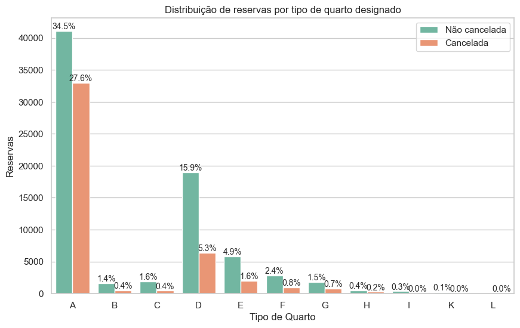

```python
plt.figure(figsize=(10, 6))

sorted_room_types = sorted(df["assigned_room_type"].unique())

ax = sns.countplot(data=df, x="assigned_room_type", hue="is_canceled", order=sorted_room_types)

total = len(df)
for p in ax.patches:
    height = p.get_height()
    if height > 0:
        width = p.get_width()
        x = p.get_x() + width / 2
        y = height
        percentage = (height / total) * 100
        ax.text(x, y + 10, f'{percentage:.1f}%', ha='center', va='bottom', fontsize=10)

plt.xlabel("Tipo de Quarto")
plt.ylabel("Reservas")
plt.title("Distribuição de reservas por tipo de quarto designado")
plt.legend(["Não cancelada", "Cancelada"])

plt.show()
```

### Distribuição do tipo de refeição

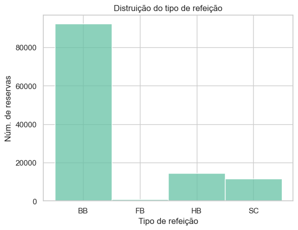

```python
sns.histplot(df["meal"], bins=20, kde=False)
plt.xlabel("Tipo de refeição")
plt.ylabel("Núm. de reservas")
plt.title("Distruição do tipo de refeição")
plt.show()
```

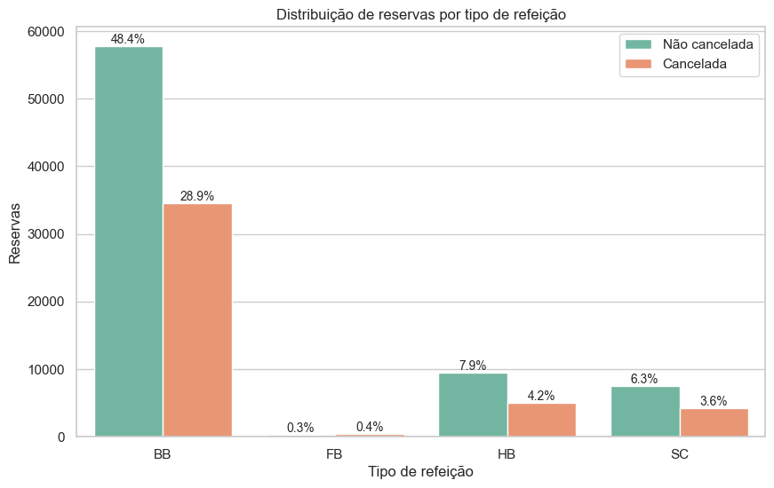

```python
plt.figure(figsize=(10, 6))

ax = sns.countplot(data=df, x="meal", hue="is_canceled")

total = len(df)
for p in ax.patches:
    height = p.get_height()
    if height > 0:
        width = p.get_width()
        x = p.get_x() + width / 2
        y = height
        percentage = (height / total) * 100
        ax.text(x, y + 10, f'{percentage:.1f}%', ha='center', va='bottom', fontsize=10)

plt.xlabel("Tipo de refeição")
plt.ylabel("Reservas")
plt.title("Distribuição de reservas por tipo de refeição")
plt.legend(["Não cancelada", "Cancelada"])

plt.show()
```

### Preço por tipo de hotel

```python
resort = df[(df["hotel"] == "Resort Hotel") & (df["is_canceled"] == 0)]
city_hotel = df[(df["hotel"] == "City Hotel") & (df["is_canceled"] == 0)]
```

```python
# Counting adults and children as paying guests only, not babies.
resort["price_per_person"] = resort["adr"] / (resort["adults"] + resort["children"])
city_hotel["price_per_person"] = city_hotel["adr"] / (city_hotel["adults"] + city_hotel["children"])
```

```python
print("""Preços médios (reservas não canceladas):
Resort: {:.2f} € por noite por pessoa.
Hotel da cidade: {:.2f} € por noite por pessoa."""
      .format(resort["price_per_person"].mean(), city_hotel["price_per_person"].mean()))
```

```
Preços médios (reservas não canceladas):
Resort: 47.49 € por noite por pessoa.
Hotel da cidade: 59.27 € por noite por pessoa.
```

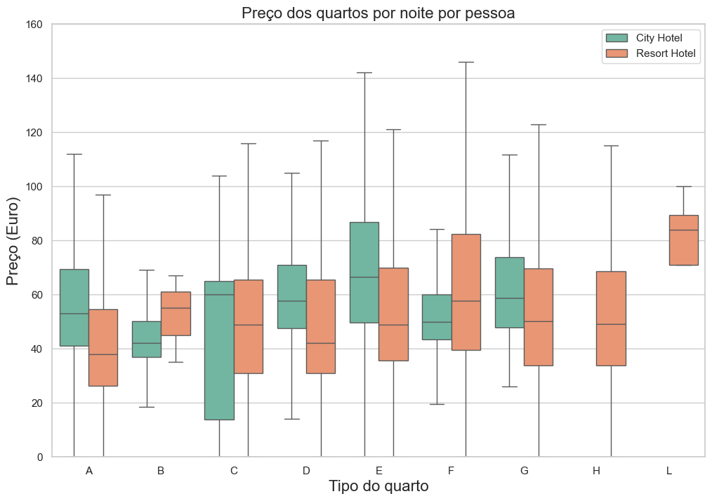

```python
df["price_per_person"] = df["adr"] / (df["adults"] + df["children"])

guests_not_canceled = df.loc[df["is_canceled"] == 0] # só clientes que se hospedaram de fato
room_prices = guests_not_canceled[["hotel", "reserved_room_type", "price_per_person"]].sort_values("reserved_room_type")

plt.figure(figsize=(12, 8))
sns.boxplot(x="reserved_room_type",
            y="price_per_person",
            hue="hotel",
            data=room_prices,
            hue_order=["City Hotel", "Resort Hotel"],
            fliersize=0)
plt.title("Preço dos quartos por noite por pessoa", fontsize=16)
plt.xlabel("Tipo do quarto", fontsize=16)
plt.ylabel("Preço (Euro)", fontsize=16)
plt.legend(loc="upper right")
plt.ylim(0, 160)
plt.show()
```

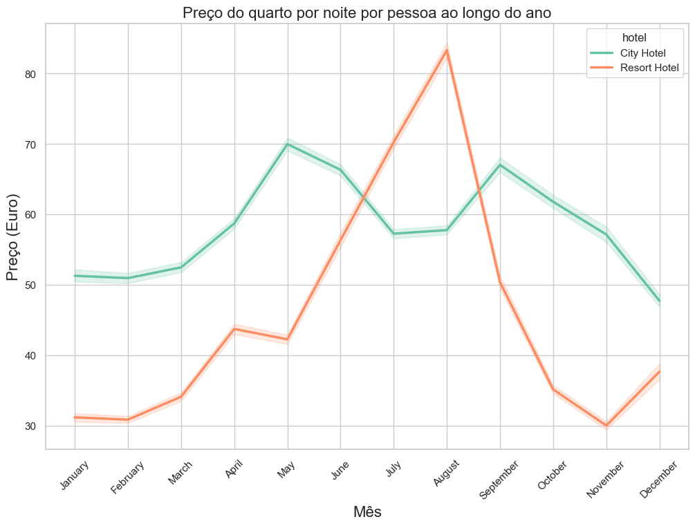

```python
room_prices_mothly = guests_not_canceled[["hotel", "arrival_date_month", "price_per_person"]].sort_values("arrival_date_month")

ordered_months = ["January", "February", "March", "April", "May", "June",
          "July", "August", "September", "October", "November", "December"]
room_prices_mothly["arrival_date_month"] = pd.Categorical(room_prices_mothly["arrival_date_month"], categories=ordered_months, ordered=True)

plt.figure(figsize=(12, 8))
sns.lineplot(x = "arrival_date_month", y="price_per_person", hue="hotel", data=room_prices_mothly,
            hue_order = ["City Hotel", "Resort Hotel"], size="hotel", sizes=(2.5, 2.5))
plt.title("Preço do quarto por noite por pessoa ao longo do ano", fontsize=16)
plt.xlabel("Mês", fontsize=16)
plt.xticks(rotation=45)
plt.ylabel("Preço (Euro)", fontsize=16)
plt.show()
```

### Cancelementos por total de pedidos especiais

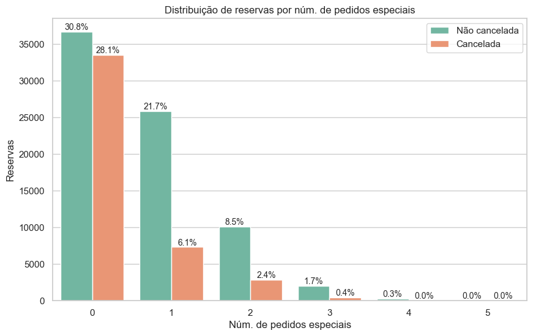

```python
plt.figure(figsize=(10, 6))

ax = sns.countplot(data=df, x="total_of_special_requests", hue="is_canceled")
total = len(df)
for p in ax.patches:
    height = p.get_height()
    if height > 0:
        width = p.get_width()
        x = p.get_x() + width / 2
        y = height
        percentage = (height / total) * 100
        ax.text(x, y + 10, f'{percentage:.1f}%', ha='center', va='bottom', fontsize=10)

plt.xlabel("Núm. de pedidos especiais")
plt.ylabel("Reservas")
plt.title("Distribuição de reservas por núm. de pedidos especiais")
plt.legend(["Não cancelada", "Cancelada"])

plt.show()
```

### Cancelamentos por núm. de vagas de carro exigidas

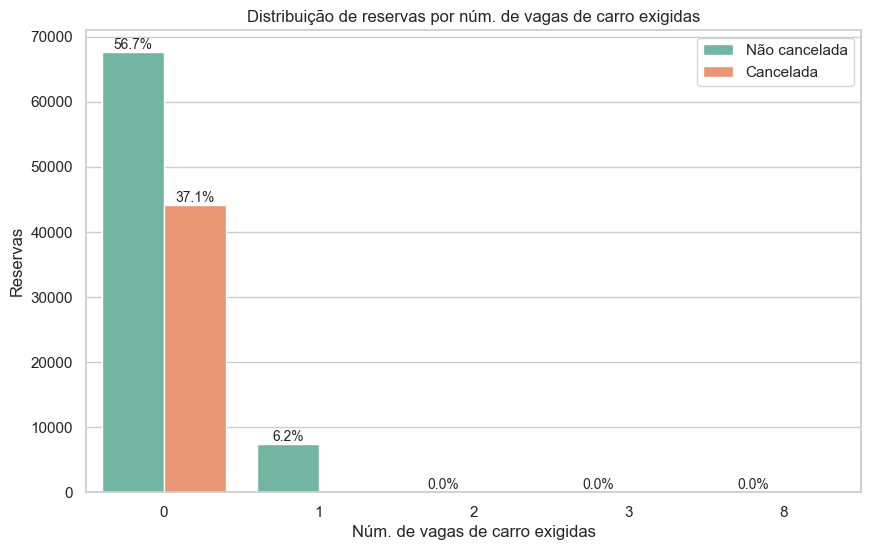

```python
plt.figure(figsize=(10, 6))

ax = sns.countplot(data=df, x="required_car_parking_spaces", hue="is_canceled")
total = len(df)
for p in ax.patches:
    height = p.get_height()
    if height > 0:
        width = p.get_width()
        x = p.get_x() + width / 2
        y = height
        percentage = (height / total) * 100
        ax.text(x, y + 10, f'{percentage:.1f}%', ha='center', va='bottom', fontsize=10)

plt.xlabel("Núm. de vagas de carro exigidas")
plt.ylabel("Reservas")
plt.title("Distribuição de reservas por núm. de vagas de carro exigidas")
plt.legend(["Não cancelada", "Cancelada"])

plt.show()
```

### Cancelamentos por núm. de mudanças na reserva

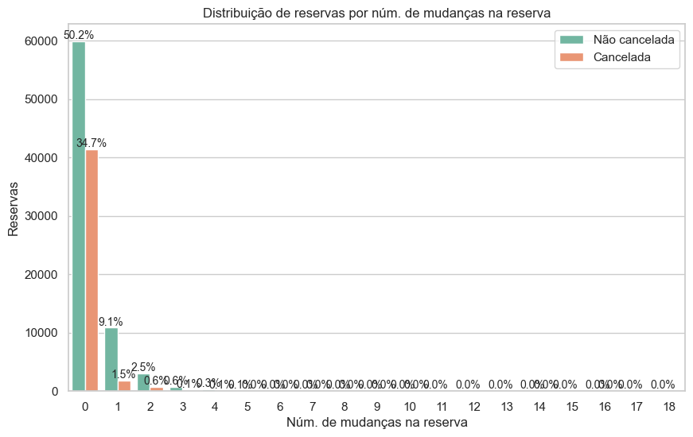

```python
plt.figure(figsize=(10, 6))

ax = sns.countplot(data=df, x="booking_changes", hue="is_canceled")
total = len(df)
for p in ax.patches:
    height = p.get_height()
    if height > 0:
        width = p.get_width()
        x = p.get_x() + width / 2
        y = height
        percentage = (height / total) * 100
        ax.text(x, y + 10, f'{percentage:.1f}%', ha='center', va='bottom', fontsize=10)

plt.xlabel("Núm. de mudanças na reserva")
plt.ylabel("Reservas")
plt.title("Distribuição de reservas por núm. de mudanças na reserva")
plt.legend(["Não cancelada", "Cancelada"])

plt.show()
```

### Correlação das variáveis numéricas

```python
corr_with_is_canceled
```

|  | is_canceled |
| --- | --- |
| is_canceled | 1.000000 |
| lead_time | 0.292876 |
| arrival_date_year | 0.016622 |
| arrival_date_week_number | 0.008315 |
| arrival_date_day_of_month | -0.005948 |
| stays_in_weekend_nights | -0.001323 |
| stays_in_week_nights | 0.025542 |
| adults | 0.058182 |
| children | 0.004851 |
| babies | -0.032569 |
| is_repeated_guest | -0.083745 |
| previous_cancellations | 0.110139 |
| previous_bookings_not_canceled | -0.057365 |
| booking_changes | -0.144832 |
| agent | -0.046770 |
| company | -0.083594 |
| days_in_waiting_list | 0.054301 |
| adr | 0.046492 |
| required_car_parking_spaces | -0.195701 |
| total_of_special_requests | -0.234877 |
| num_guests | 0.044826 |
| price_per_person | 0.017808 |

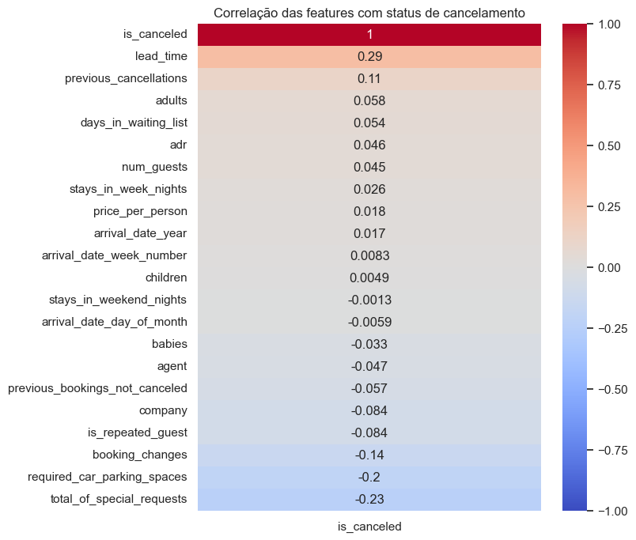

```python
correlations = df.corr(numeric_only=True)
corr_with_is_canceled = correlations[['is_canceled']]

plt.figure(figsize=(7, 8))
sns.heatmap(corr_with_is_canceled.sort_values(by='is_canceled', ascending=False), annot=True, cmap='coolwarm', vmin=-1, vmax=1)
plt.title("Correlação das features com status de cancelamento")
plt.show()
```

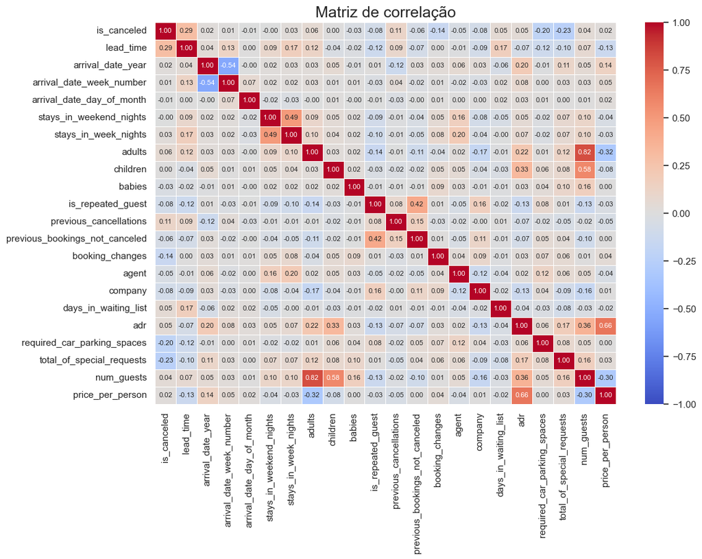

```python
numeric_df = df.select_dtypes(include=['number'])

plt.figure(figsize=(12, 8))

sns.heatmap(correlations, annot=True, cmap='coolwarm', fmt='.2f', vmin=-1, vmax=1, linewidths=0.5, annot_kws={"size": 8} )

plt.title('Matriz de correlação', fontsize=18)
plt.show()
```

### Conclusões da análise dos dados

- O Hotel da cidade apresenta uma proporção de cancelamentos maior que o resort (41% vs 27%);
- A maior parte dos hóspedes é oriundo da europa, principalmente de Portugal, país onde hotéis estão localizados;
- A maior parte das reservas é feita para 2 pessoas; O impacto do tempo de antecedência da reserva nos cancelamentos foi evidente: reservas feitas com muita antecedência apresentam uma maior taxa de cancelamento, indicando que clientes podem planejar viagens com mais flexibilidade e mudar de ideia posteriormente;
- Reservas com depósito não reembolsado tem uma taxa de cancelamento altíssima (~100%);
- Quartos do hotel da cidade tem preço por noite levemente maior para maioria das categorias;
- Quartos do resort tem preços consideravelmente maiores nos meses do verão europeu (julho-agosto);
- A variável com a maior correlação em relação ao status de cancelamento é a "lead_time" (tempo entre reserva e chegada);
- Quanto mais pedidos especiais e vagas de carro exigidas, menor a tendência de cancelar a reserva;
- Hóspedes que realizam pelo menos uma mudança na reserva tendem a cancelar menos;
- Hóspedes que repetem estadia tendem a cancelar menos.

## Regressão logística

### Features escolhidas

As seguintes *features* serão desconsideradas para evitar vazamento de dados):

- **arrival_date_year** → Viés temporal (overfitting para anos específicos).
- **assigned_room_type** → Informação pós-reserva (não disponível no momento da reserva).
- **booking_changes** → Vazamento direto (modificações ocorrem após a reserva).
- **reservation_status** → 100% de vazamento (indica diretamente se a reserva foi cancelada).
- **days_in_waiting_list** → Indicador pós-reserva (não disponível no momento da reserva).

Além dessa *features*, serão removidos:

- **country** → Pode introduzir viés, reduzindo a generalização.

```python
num_features = ["lead_time","arrival_date_week_number","arrival_date_day_of_month",
                "stays_in_weekend_nights","stays_in_week_nights","adults","children",
                "babies","is_repeated_guest", "previous_cancellations",
                "previous_bookings_not_canceled","agent","company",
                "required_car_parking_spaces", "total_of_special_requests", "adr"]

cat_features = ["hotel","arrival_date_month","meal","market_segment",
                "distribution_channel","reserved_room_type","deposit_type","customer_type"]
```

```python
features = num_features + cat_features

df_with_dummies = pd.get_dummies(df[cat_features], columns=cat_features, drop_first=True, dtype=int)

X = pd.concat([df[num_features], df_with_dummies], axis=1)
y = df["is_canceled"]
```

```python
X_train, X_test, y_train, y_test = train_test_split(X, y, test_size=0.2, random_state=42)
```

```python
log_reg = LogisticRegression(max_iter=1000, class_weight='balanced')
log_reg.fit(X_train, y_train)
```

```
LogisticRegression(class_weight='balanced', max_iter=1000)
```

```
AUC: 0.8507
```

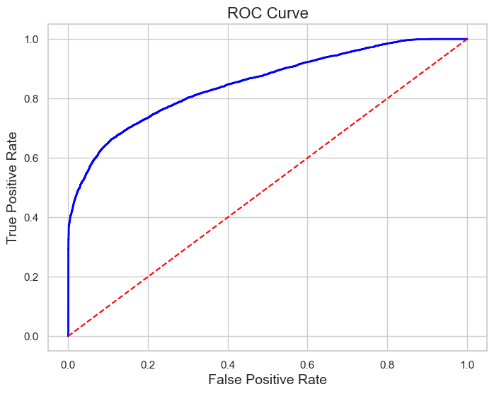

```
Precisão: 0.7111
Sensitividade (Recall): 0.7159
Especificidade: 0.8272
```

```python
y_pred_proba = log_reg.predict_proba(X_test)[:, 1]
y_pred = log_reg.predict(X_test)

auc = roc_auc_score(y_test, y_pred_proba)
print(f'AUC: {auc:.4f}')

fpr, tpr, thresholds = roc_curve(y_test, y_pred_proba)
plt.figure(figsize=(8, 6))
plt.plot(fpr, tpr, color='blue', lw=2)
plt.plot([0, 1], [0, 1], color='red', linestyle='--')  # Diagonal line
plt.xlabel('False Positive Rate', fontsize=14)
plt.ylabel('True Positive Rate', fontsize=14)
plt.title('ROC Curve', fontsize=16)
plt.show()

precision = precision_score(y_test, y_pred)
sensitivity = recall_score(y_test, y_pred)
cm = confusion_matrix(y_test, y_pred)

tn, fp, fn, tp = cm.ravel()
specificity = tn / (tn + fp)

print(f'Precisão: {precision:.4f}')
print(f'Sensitividade (Recall): {sensitivity:.4f}')
print(f'Especificidade: {specificity:.4f}')
```

```python
report = classification_report(y_test, y_pred)
print("Classification Report:\n", report)
```

```
Classification Report:
               precision    recall  f1-score   support

           0       0.83      0.83      0.83     14958
           1       0.71      0.72      0.71      8884

    accuracy                           0.79     23842
   macro avg       0.77      0.77      0.77     23842
weighted avg       0.79      0.79      0.79     23842
```

### Impacto das variáveis

```python
coefficients = log_reg.coef_[0]

coef_df = pd.DataFrame({
    'Variável': X_train.columns,
    'Coeficiente': coefficients,
    'Impacto': np.exp(coefficients)
})

coef_df = coef_df.sort_values(by='Impacto', ascending=False)

print(coef_df)
```

```
                          Variável  Coeficiente     Impacto
50         deposit_type_Non Refund     5.554447  258.384127
9           previous_cancellations     2.950923   19.123597
53         customer_type_Transient     0.730451    2.076016
36        market_segment_Online TA     0.431028    1.538839
28                         meal_FB     0.419379    1.521017
18     arrival_date_month_December     0.314435    1.369485
25     arrival_date_month_November     0.211260    1.235233
6                         children     0.166883    1.181616
43            reserved_room_type_C     0.145961    1.157151
54   customer_type_Transient-Party     0.111548    1.118007
5                           adults     0.091833    1.096182
45            reserved_room_type_E     0.088002    1.091990
26      arrival_date_month_October     0.085923    1.089722
31    market_segment_Complementary     0.071527    1.074147
```

[output cut: 41 more lines]

### Adicionando "country"

```python
cat_features = cat_features + ["country"]
features = num_features + cat_features

df_with_dummies = pd.get_dummies(df[cat_features], columns=cat_features, drop_first=True, dtype=int)

X = pd.concat([df[num_features], df_with_dummies], axis=1)
y = df["is_canceled"]
```

```python
X_train, X_test, y_train, y_test = train_test_split(X, y, test_size=0.2, random_state=42)
```

```python
log_reg = LogisticRegression(max_iter=1000, class_weight='balanced')
log_reg.fit(X_train, y_train)
```

```
LogisticRegression(class_weight='balanced', max_iter=1000)
```

```python
y_pred = log_reg.predict(X_test)
```

```python
report = classification_report(y_test, y_pred)
print("Classification Report:\n", report)
```

```
Classification Report:
               precision    recall  f1-score   support

           0       0.85      0.82      0.84     14958
           1       0.72      0.76      0.74      8884

    accuracy                           0.80     23842
   macro avg       0.79      0.79      0.79     23842
weighted avg       0.80      0.80      0.80     23842
```

#### Impacto das variáveis

```python
coefficients = log_reg.coef_[0]

coef_df = pd.DataFrame({
    'Variável': X_train.columns,
    'Coeficiente': coefficients,
    'Impacto': np.exp(coefficients)
})

coef_df = coef_df.sort_values(by='Impacto', ascending=False)

print(coef_df)
```

```
                         Variável  Coeficiente    Impacto
50        deposit_type_Non Refund     4.395069  81.050257
9          previous_cancellations     2.309628  10.070679
189                   country_PRT     1.596482   4.935640
36       market_segment_Online TA     0.866876   2.379467
85                    country_CHN     0.805738   2.238347
..                            ...          ...        ...
32       market_segment_Corporate    -0.792365   0.452773
35   market_segment_Offline TA/TO    -0.807577   0.445937
97                    country_DEU    -0.835079   0.433840
8               is_repeated_guest    -1.150548   0.316463
13    required_car_parking_spaces    -4.566961   0.010389

[232 rows x 3 columns]
```

### Reduzindo número de features

Selecionando *features* com coeficiente > 0.1 ou < -0.1

```python
new_features = coef_df[(coef_df['Coeficiente'] > 0.1) | (coef_df['Coeficiente'] < -0.1)]['Variável'].values
```

```python
X_train, X_test, y_train, y_test = train_test_split(X[new_features], y, test_size=0.2, random_state=42)
```

```python
log_reg = LogisticRegression(max_iter=1000, class_weight='balanced')
log_reg.fit(X_train, y_train)
```

```
LogisticRegression(class_weight='balanced', max_iter=1000)
```

```python
y_pred = log_reg.predict(X_test)
```

```python
report = classification_report(y_test, y_pred)
print("Classification Report:\n", report)
```

```
Classification Report:
               precision    recall  f1-score   support

           0       0.83      0.76      0.80     14958
           1       0.65      0.74      0.69      8884

    accuracy                           0.75     23842
   macro avg       0.74      0.75      0.74     23842
weighted avg       0.76      0.75      0.76     23842
```

Um modelo mais simples apresentou resultado inferior ao modelo original.

## Análise das features e conclusões

### Análise das Features

A análise dos coeficientes do modelo de **Regressão Logística** para prever a variável `is_canceled` revela que os fatores mais relevantes para o cancelamento de reservas são: **`deposit_type_Non Refund`**, **`previous_cancellations`** e **`customer_type_Transient`**. O maior impacto positivo está no tipo de depósito **não reembolsável** (**coeficiente = 5.55**), indicando que clientes que optam por esse tipo de pagamento têm uma probabilidade muito maior de cancelamento. Da mesma forma, hóspedes com **cancelamentos prévios** (**coeficiente = 2.95**) apresentam forte tendência de cancelar novamente. Além disso, clientes **transitórios** (**coeficiente = 0.73**)—que costumam fazer reservas curtas e de última hora—também estão mais propensos ao cancelamento.

Outras variáveis que impactam positivamente a previsão incluem **o segmento de mercado `market_segment_Online TA`**, que representa reservas feitas por agências online, e a presença de **crianças (`children`)** na reserva. Já variáveis como **`is_repeated_guest`** (**coeficiente = -0.78**) e **`total_of_special_requests`** (**coeficiente = -0.72**) possuem coeficientes negativos, indicando que hóspedes frequentes e aqueles que fazem pedidos especiais são menos propensos a cancelar suas reservas.

Dentre os fatores com impacto negativo mais significativo, destaca-se a variável **`required_car_parking_spaces`** (**coeficiente = -4.22**), sugerindo que clientes que necessitam de estacionamento têm menor probabilidade de cancelar. Além disso, **reservas feitas via canais diretos (`distribution_channel_Direct`)** e segmentos como **"Corporate" e "Groups"** também estão associadas a uma menor taxa de cancelamento.

### Justificativa do Método

A **Regressão Logística** é a técnica mais adequada para este problema, pois a variável de interesse, `is_canceled`, é **binária** (**0 = reserva mantida, 1 = reserva cancelada**). Diferente da **Regressão Linear**, que assume uma relação contínua entre variáveis e pode gerar previsões fora do intervalo `[0,1]`, a **Regressão Logística** utiliza a função sigmoide para modelar a **probabilidade de cancelamento**, garantindo previsões coerentes.

Além disso, o modelo permite interpretar diretamente o impacto das variáveis em termos de **log-odds**, o que facilita a compreensão de quais fatores aumentam ou diminuem a probabilidade de cancelamento. Dessa forma, a **Regressão Logística** se mostra mais eficaz e interpretável para este tipo de problema de classificação.

### Conclusão

#### Comparação dos Modelos

Foram testados três modelos de Regressão Logística para prever o cancelamento de reservas (is_canceled):

##### Análise dos Resultados

**Modelo Completo** Acurácia: 0.79 Precisão Classe 1 (Cancelamento): 0.71 Recall Classe 1: 0.72 F1-score Classe 1: 0.71 ➡️ Bom equilíbrio entre precisão e recall. O modelo completo capta bem os padrões de cancelamento, mas pode ter alguma redundância de features.

**Modelo com feature "country"** Acurácia: 0.80 Precisão Classe 1: 0.72 Recall Classe 1: 0.76 F1-score Classe 1: 0.74 ➡️ Melhor recall para cancelamentos (0.76), indicando que este modelo é mais eficaz em identificar reservas que serão canceladas. Isso sugere que a localização do hóspede (country) tem um impacto significativo no cancelamento de reservas. ➡️ **Problema:** nem sempre no momento da reserva haverá a presença da *feature* contendo o país de origem (de fato ou preenchido pelo cliente)

**Modelo com coeficientes relevantes (>|0.1|)** Acurácia: 0.75 Precisão Classe 1: 0.65 Recall Classe 1: 0.74 F1-score Classe 1: 0.69 ➡️ Desempenho inferior aos outros dois modelos. Apesar de filtrar features menos impactantes, a remoção de algumas variáveis pode ter prejudicado a captura de padrões importantes, reduzindo a precisão e a acurácia geral.